# Predicting Student Performance

STOR 390: Group 5

Authors: Valerie Davis, Trent Hollandsworth, Matthew Conway

[University of North Carolina at Chapel Hill, STOR390: Introduction to Data Science, Spring 2017](https://idc9.github.io/stor390/)

Better understanding of trends in education can have an enormous impact on how schools help individual students succeed. By understanding what factors affect student performance, schools can help reduce drop out rates, increase test scores, and produce well-educated students. To this end, we analyzed a data set of Portuguese secondary students, which contained information about their personal and academic situations and grades. In particular, we were curious about what relationships may exist between a student’s grades and their demographic, social, and school circumstances. Do students with more absences or high weekday alcohol consumption perform poorly in relation to their peers? Does studying and extra paid instruction correspond with higher grades? Additionally, we were interested in how these factors influence each other. For example, is there a difference in drinking habits of male and female students?

### The Data

The dataset we used was originally a part of a 2008 paper [^1] by Cortez and Silva. The student’s grades are specifically from Math and Portuguese classes because those classes tend to be good predictors of overall student success. They found that the first and second period grades were very significant when predicting a student’s final grade using several types of data mining techniques. We aimed to create a predictive model that was informative without using previous grades. Such a model would give schools and educators an idea of which students needed extra help earlier in the year, giving them more time to provide support. Cortez and Silva used all of the other student data when creating their models, but we wanted to find which inputs (besides previous grades) were the most influential and best predictors.

Students were graded on a scale from 0 to 20. Quite a large number of students received as 0 as their final grade. We assumed that other, undocumented factors led to that final score (e.g. the student did not take the assessment) and therefore removed these observations from the data. We also removed the sole student with a final grade of 1 as an outlier.

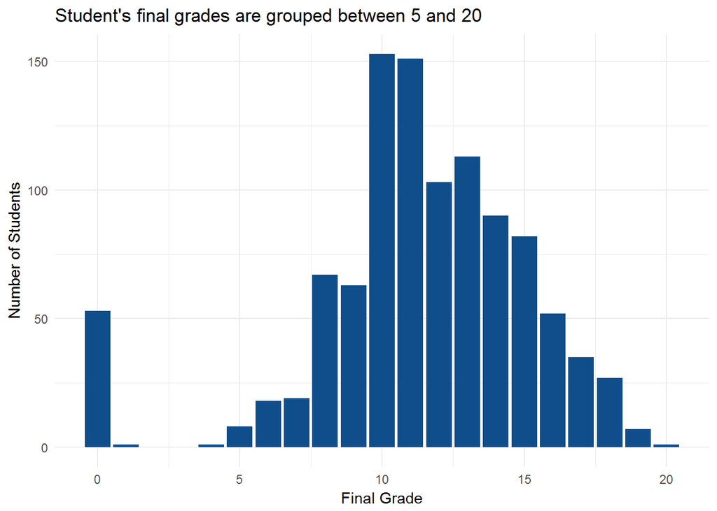

### Factors Affecting Final Grades

We started by looking at the relationship between almost every input variable and final grades. This included elements that we presumed would correlate to higher grades such as studying, interest in higher education, nursery school attendance, and higher educated parents. Things we assumed would be related to poor scores included high absence rate, past failures, high alcohol consumption, and poor health.

We look at a few of these individually below.

##### Studying

Is our intuition that students who study more perform better correct? We see in the plot below that on average, final grades increase as study time increases. However, this is not by much; the average grade for those who studied less than 2 hours a week is only about 2 points lower than those who studied more than 10 hours.

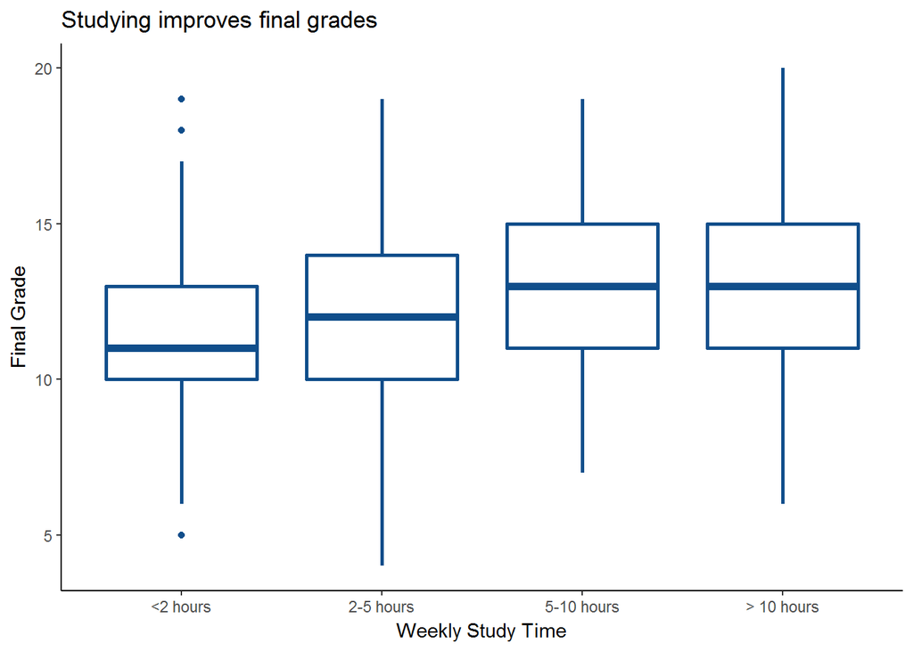

##### Absences

As expected, the more time a student is absent during the year, the lower their final grade is. However, we do not know if the lower grade is specifically because they missed class and the information taught that day. It’s possible that the reason they are absent (e.g. health issues) is actually the causing the lower grade.

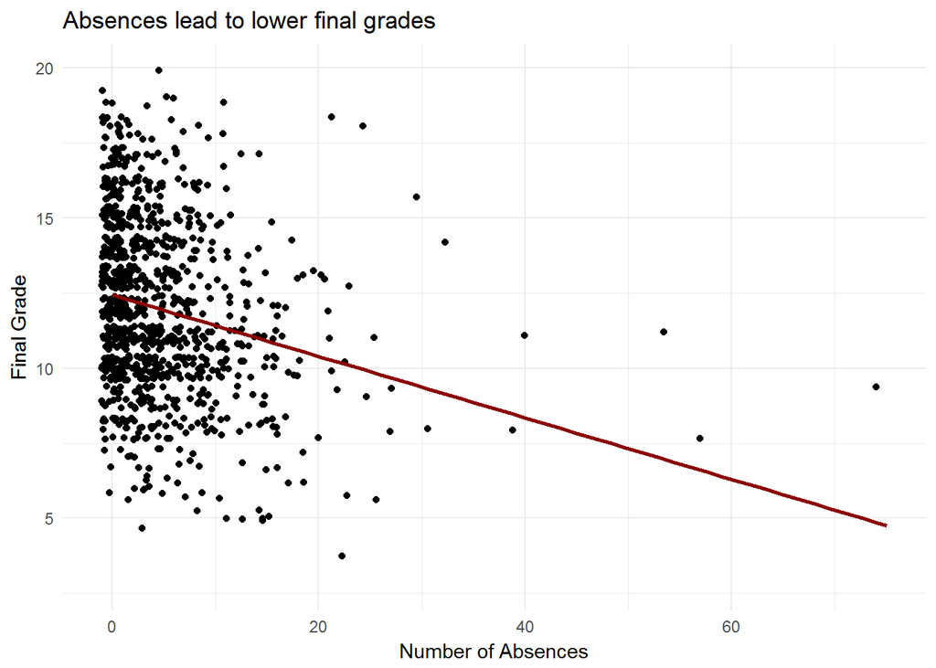

##### Parent’s Education

A student’s final grade increases the higher of level of education that their parents have. The plot for the mother’s education is below. We also found that family educational support increases with the parents’ education. This is logical, as parents with higher levels of education backgrounds would be more prepared to help their student with homework or other education needs.

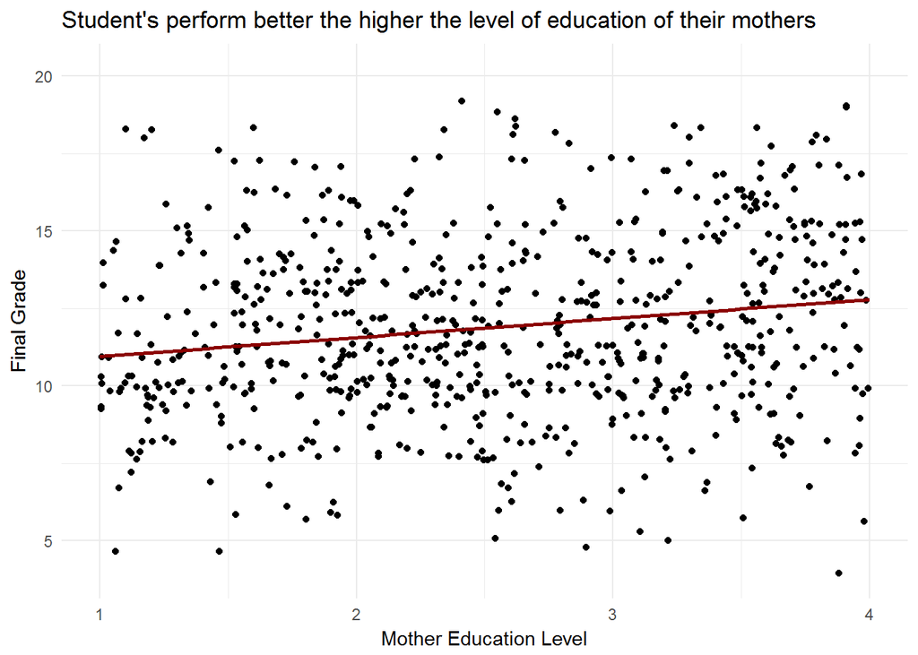

##### Health

The following graph has an interesting result, as the healthiest group of students have one of the lowest average grades (which is somewhat counterintuitive). However, the difference in average grades in by less than 1 point among all health levels.

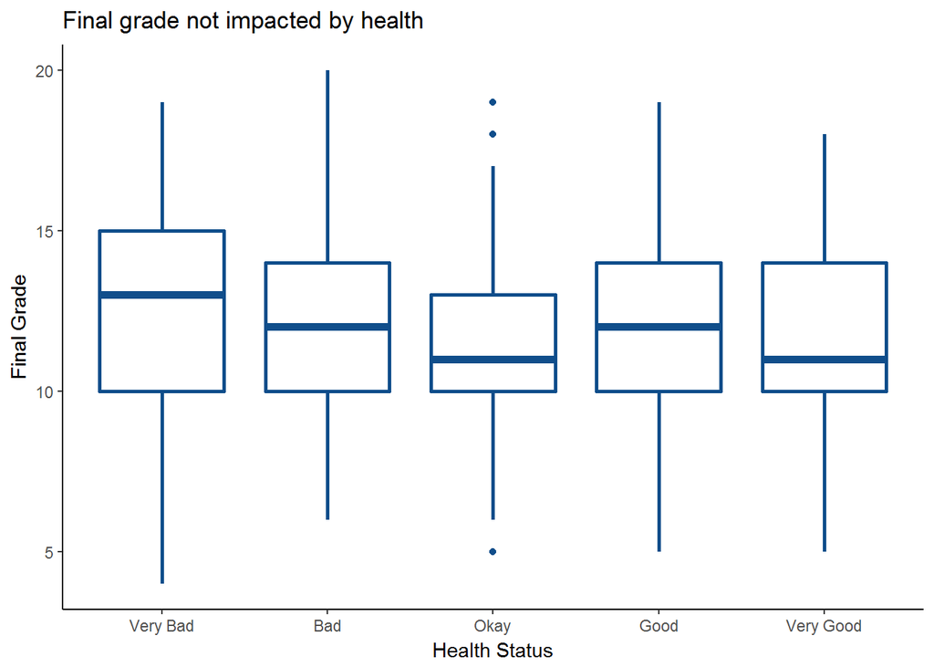

### Modeling Student Performance

We created several linear models to attempt to predict a student’s final grade. The first five we hand chose which variables to include based on earlier analysis and intuition. For the last two we used a automatic selection method (stepwise). The variables for each model are as follows:

1. All available inputs
2. Age, travel time to school, number of absences, weekday alcohol consumption, first two period grades, subject of class, frequency of going out with friends, school and family education support, taking additional paid classes in the subject
3. Taking additional paid classes in the subject, frequency of going out with friends, number of absences, weekday alcohol consumption, and first 2 period grades, subject of class
4. All of variables in 3 as well as the interaction of the first 2 period grades and those grades squared
5. Taking additional paid classes in the subject, frequency of going out with friends, number of absences, weekday alcohol consumption, subject of class

Originally, we had wanted to not use the first and second period grades. But if we didn’t, the mean squared error rate was over 5! This means, on average, the squared difference of our predicted grade and the actual grade was over 5. We decided including those grades was worth it to have models that are more accurate.

#### Error in Linear Models

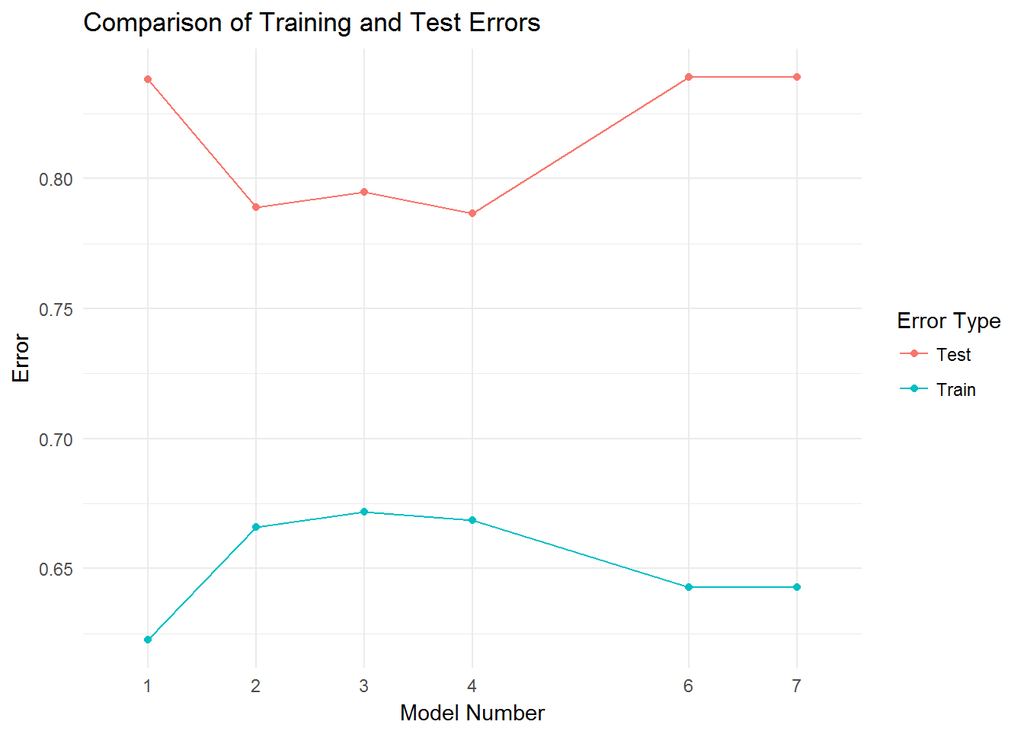

### Other Interesting Relationships

We were also interested in the relationships between the student’s demographic, social, and school circumstances. Below we explore a few of our more interesting findings.

#### Why Students Choose a School

We can see below that a higher percentage of the students at Gabriel Pereira chose that school for it’s reputation. It makes sense that Gabriel Pereira would have a better reputation, since it has higher scores in both Math and Portuguese.

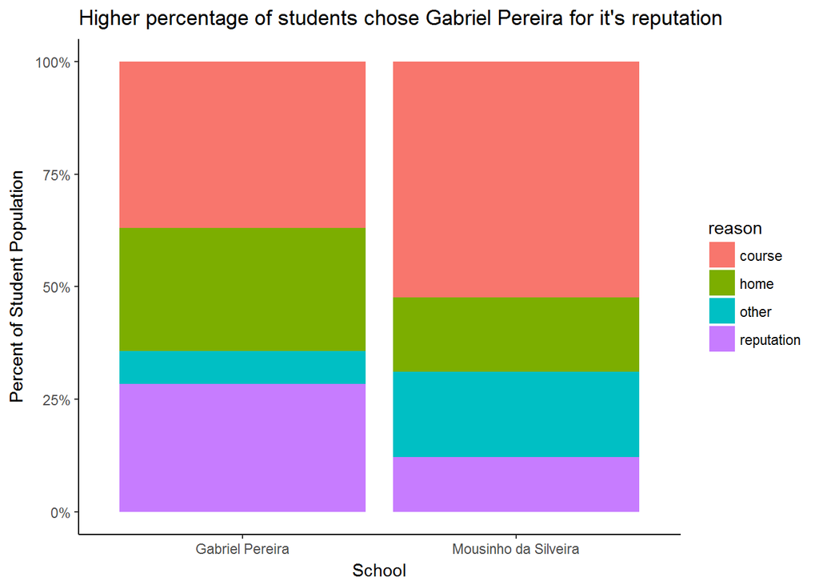

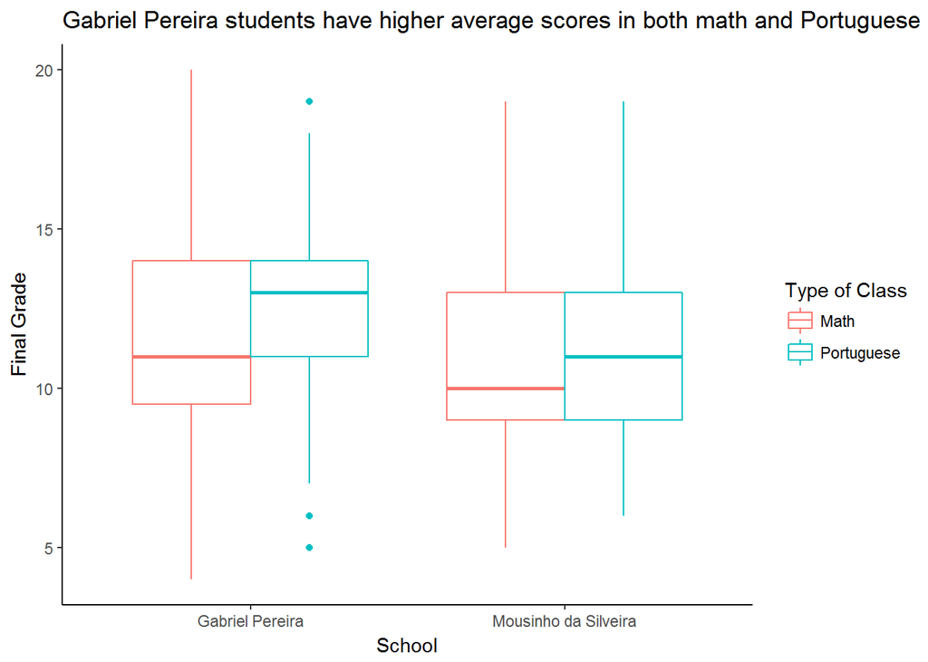

#### Genders and Drinking Habits

Male students drink more than females, but both genders increase their consumption over the weekend.

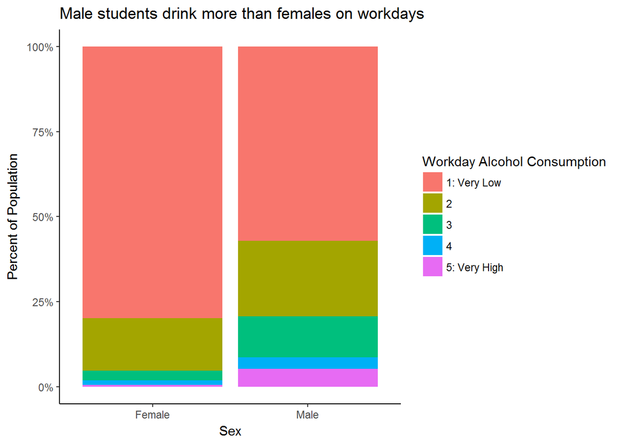

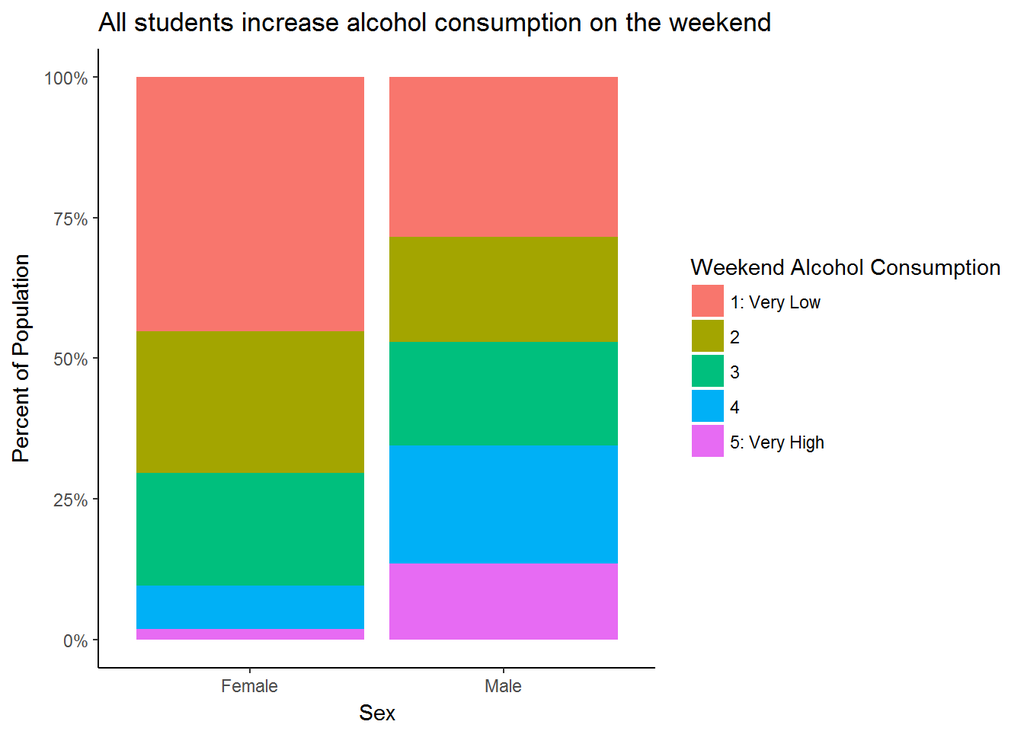

#### Romantic Relationships

Being in a romantic relationship does not seem to have a negative connection with time spend studying.

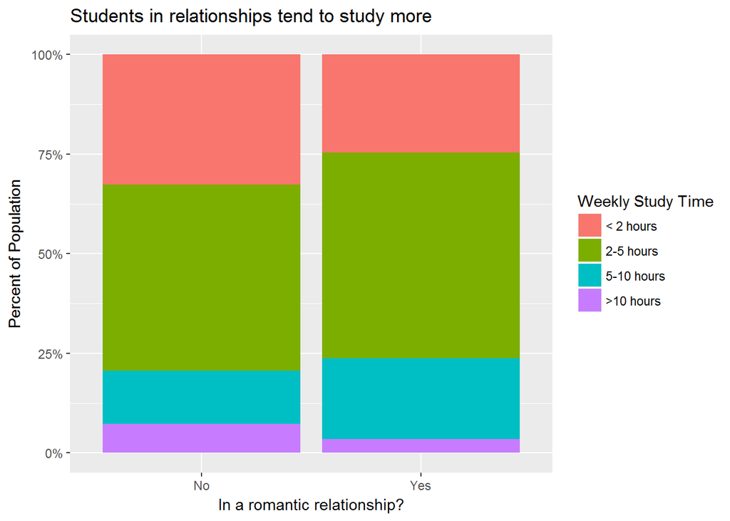

[^1]: [Using Data Mining to Predict Secondary School Student Performance, P. Cortez and A. Silva](http://www3.dsi.uminho.pt/pcortez/student.pdf)